# BDSI R Markdown: Exercise 2

14-June-2021

# Main header

This exercise assumes you are reading the `R` script and not the knitted output. **Task 1** Add yourself as the author of this document on line 3.

**Task 2** *Knit* this document using *Cmd+Shift+K* / *Ctrl+Shift+K*. Note how Markdown creates an automatic table of contents with click-able links.

**Task 3** On line 7 change `html_document` to `word_document`, and on line 11 change `word_document` to `html_document`. **knitr** will pay attention only to the first output selection and ignore all others. Don’t worry if what you knit doesn’t look very pretty as a .docx. Now undo what you just did so that your selected output format is again a html

## Sub header

Note the clever use of the # sign at the beginning of each line number. As usual, “regular” `R` will ignore any line that starts with a #, as these do. Thus, you can treat this script exactly as you would any other `R` script. But, when you knit this script using **knitr**, the #’ (the hash followed by an apostrophe) indicates to that this is actually markdown text and should be interpreted as such. **Task 4** Add some more text after this sentence and then press *enter* or *return*. RStudio should automatically added an #’ at the beginning of each new line that you start.

## Keeping track of your margins

Your knitted document is not affected by single linebreaks. That is, you can press ‘enter’ once without affecting the appearance of your final document. On the other hand, two linebreaks denote a new paragraph. Take advantage of this feature to maintain the readability of your text by starting a new line before you start to spill off the screen of your text editor, like this: Lorem ipsum dolor sit amet, consectetur adipiscing elit, sed do eiusmod tempor incididunt ut labore et dolore magna aliqua. Ut enim ad minim veniam, quis nostrud exercitation ullamco laboris nisi ut aliquip ex ea commodo consequat. Duis aute irure dolor in reprehenderit in voluptate velit esse cillum dolore eu fugiat nulla pariatur. Excepteur sint occaecat cupidatat non proident, sunt in culpa qui officia deserunt mollit anim id est laborum.

On my RStudio application, I have set it to denote an 80-character width, which is the approximate point at which I try to jump to a new line when I’m typing.

**Task 6** To do this on your own app: go to the RStudio menu, then Preferences > Code > Display > Show Margin. Then enter your desired width. After pressing ‘Ok’, you should see a slight vertical line somewhere towards the right of your screen (depending on your chosen number).

## Some data analysis

I’m using an in-line chunk to report that the observed mean of `x` is -2.0827 **Task 7** Add another in-line chunk to report the observed standard deviation of `x`.

## The Datasaurus dozen

```r
if(!require(datasauRus, quietly = TRUE)) {install.packages("datasauRus",repos = "http://cran.us.r-project.org");library(datasauRus)}

# If the package is installed and you just want to load it, you can also use this code:

library(datasauRus);
```

The first chunk you ran above checks to see if a particular package (`datasauRus`, keep reading for a description of these packages) is *installed* on your computer, i.e. downloaded onto your hard drive. After installing a package, you generally only ever need to re-install it if you’ve updated `R` or if the package is updated. Thus, the chunk first checks to see if each package has already been installed before trying to re-install it.

Here’s what the top of the datasauras dataset looks like in raw form:

```r
as_tibble(datasaurus_dozen);
```

```
## # A tibble: 1,846 × 3
##    dataset     x     y
##    <chr>   <dbl> <dbl>
##  1 dino     55.4  97.2
##  2 dino     51.5  96.0
##  3 dino     46.2  94.5
##  4 dino     42.8  91.4
##  5 dino     40.8  88.3
##  6 dino     38.7  84.9
##  7 dino     35.6  79.9
##  8 dino     33.1  77.6
##  9 dino     29.0  74.5
## 10 dino     26.2  71.4
## # … with 1,836 more rows
```

There are 13 individual datasets included in this dataset, and we can summarize the characteristics of each dataset with this code:

```r
datasaurus_summarized <-
  datasaurus_dozen %>%
  group_by(dataset) %>%
  summarize(mean_x = mean(x),
            mean_y = mean(y),
            std_dev_x = sd(x),
            std_dev_y = sd(y),
            corr_x_y = cor(x, y));
print(datasaurus_summarized)
```

```
## # A tibble: 13 × 6
##    dataset    mean_x mean_y std_dev_x std_dev_y corr_x_y
##    <chr>       <dbl>  <dbl>     <dbl>     <dbl>    <dbl>
##  1 away         54.3   47.8      16.8      26.9  -0.0641
##  2 bullseye     54.3   47.8      16.8      26.9  -0.0686
##  3 circle       54.3   47.8      16.8      26.9  -0.0683
##  4 dino         54.3   47.8      16.8      26.9  -0.0645
##  5 dots         54.3   47.8      16.8      26.9  -0.0603
##  6 h_lines      54.3   47.8      16.8      26.9  -0.0617
##  7 high_lines   54.3   47.8      16.8      26.9  -0.0685
##  8 slant_down   54.3   47.8      16.8      26.9  -0.0690
##  9 slant_up     54.3   47.8      16.8      26.9  -0.0686
## 10 star         54.3   47.8      16.8      26.9  -0.0630
## 11 v_lines      54.3   47.8      16.8      26.9  -0.0694
## 12 wide_lines   54.3   47.8      16.8      26.9  -0.0666
## 13 x_shape      54.3   47.8      16.8      26.9  -0.0656
```

Here is how these same summary data look like using **knitr**’s `kable` command:

```r
kable(datasaurus_summarized);
```

| dataset | mean_x | mean_y | std_dev_x | std_dev_y | corr_x_y |
| --- | --- | --- | --- | --- | --- |
| away | 54.27 | 47.83 | 16.77 | 26.94 | -0.0641 |
| bullseye | 54.27 | 47.83 | 16.77 | 26.94 | -0.0686 |
| circle | 54.27 | 47.84 | 16.76 | 26.93 | -0.0683 |
| dino | 54.26 | 47.83 | 16.77 | 26.94 | -0.0645 |
| dots | 54.26 | 47.84 | 16.77 | 26.93 | -0.0603 |
| h_lines | 54.26 | 47.83 | 16.77 | 26.94 | -0.0617 |
| high_lines | 54.27 | 47.84 | 16.77 | 26.94 | -0.0685 |
| slant_down | 54.27 | 47.84 | 16.77 | 26.94 | -0.0690 |
| slant_up | 54.27 | 47.83 | 16.77 | 26.94 | -0.0686 |
| star | 54.27 | 47.84 | 16.77 | 26.93 | -0.0630 |
| v_lines | 54.27 | 47.84 | 16.77 | 26.94 | -0.0694 |
| wide_lines | 54.27 | 47.83 | 16.77 | 26.94 | -0.0666 |
| x_shape | 54.26 | 47.84 | 16.77 | 26.93 | -0.0656 |

We can also use the **kableExtra** package to make our tables extra fancy. However, this makes use of some features that will not work for all file formats.

**Task 8** To see this, go back to the YAML header of this document and, again, On line 7 change `html_document` to `word_document`, and on line 11 change `word_document` to `html_document`. After knitting, go back to this table: it’s just a jumbled mess. Do the same thing, now knitting to a pdf (knitting to a pdf will only work if you have a Tex distribution installed). The knitted pdf should have stripes; the html version will not.

The takeaway is this: although you *can* always knit your script to different formats, it will not always be formatted as expected. MS Word files are very different from html, which are very different from pdf files. I find pdf files to be the most pleasing to look at and easiest to share with collaborators.

```r
if(!require(kableExtra, quietly = TRUE)) {install.packages("kableExtra",repos = "http://cran.us.r-project.org");library(kableExtra);}
kable(datasaurus_summarized,
      booktabs = T) %>%
  kable_styling(latex_options = c("striped"),
                stripe_color = "#DFDFDF") %>%
  add_header_above(c(" " = 1, "Summary statistics" = 5));
```

| dataset | Summary statistics mean_x | Summary statistics mean_y | Summary statistics std_dev_x | Summary statistics std_dev_y | Summary statistics corr_x_y |
| --- | --- | --- | --- | --- | --- |
| away | 54.27 | 47.83 | 16.77 | 26.94 | -0.0641 |
| bullseye | 54.27 | 47.83 | 16.77 | 26.94 | -0.0686 |
| circle | 54.27 | 47.84 | 16.76 | 26.93 | -0.0683 |
| dino | 54.26 | 47.83 | 16.77 | 26.94 | -0.0645 |
| dots | 54.26 | 47.84 | 16.77 | 26.93 | -0.0603 |
| h_lines | 54.26 | 47.83 | 16.77 | 26.94 | -0.0617 |
| high_lines | 54.27 | 47.84 | 16.77 | 26.94 | -0.0685 |
| slant_down | 54.27 | 47.84 | 16.77 | 26.94 | -0.0690 |
| slant_up | 54.27 | 47.83 | 16.77 | 26.94 | -0.0686 |
| star | 54.27 | 47.84 | 16.77 | 26.93 | -0.0630 |
| v_lines | 54.27 | 47.84 | 16.77 | 26.94 | -0.0694 |
| wide_lines | 54.27 | 47.83 | 16.77 | 26.94 | -0.0666 |
| x_shape | 54.26 | 47.84 | 16.77 | 26.93 | -0.0656 |

Visually, the datasets look much different:

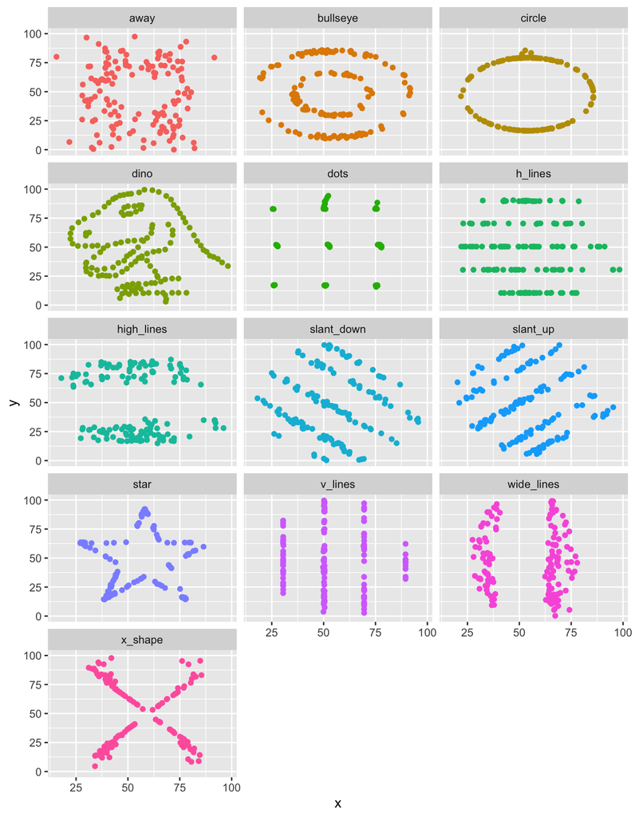

Same summary statistics, different plots. Roar!

```r
dino_plot <-
  ggplot(datasaurus_dozen) +
  geom_point(mapping = aes(x = x, y = y, color = dataset)) +
  theme_grey() +
  theme(legend.position = "none") +
  facet_wrap(~dataset, ncol = 3);
print(dino_plot);
```